# Assignment SQL - R

Anil Akyildirim

2019-09-06

## Introduction

In this assignment, we have been asked to do a survey within our family and friends, where they rate six recent popular movies from scale of 1 to 5. The observations would be captured and stored in an SQL database and loaded into an R dataframe.

## About the Survey

The focus of the survey was mainly to capture everyone’s ratings. Questions and description of each variable are outlined below;

1- What is your name?

2- From 1 to 5, what do you rate movie (Avengers, Lion King, Joker, Spiderman, Aladdin, Captain_Marvel)?

3- What is your age?

4- What is your gender?

5- What is our relationship?

1- name: Name of the individual

2- rating: From 1 to 5 the rating of the movie provided by the individual.

3- age: age of the individual

4- gender: gender of the individiual.

5- type: relationship between the surveyer and the individual.

6- Addition to the questions since we selected the movies as a drop down option for individuals to select, movie_name: Name of the Movie.

## Creating the MySQL Database

The survey results are collected in a spreadhseet and saved [here](https://raw.githubusercontent.com/anilak1978/movies-survey/master/movie_ratings.csv). Addition to the survey, we can use google to find additional information for the particular movies such as, genre, year made and cost (in millions). This spreadhseet is saved [here](https://raw.githubusercontent.com/anilak1978/movies-survey/master/movie_data_set.csv)

In order to create the database, we have to create an sql instance , create a schema and required tables for further load into the R dataframe. The .sql file can be found [here](https://github.com/anilak1978/movies-survey). In the process we can create multiple tables, filter and merge variables if we want to.

## Loading the MySQL Database and Tables in R

```r
# installing required packages

install.packages("RMariaDB", repos = "http://cran.us.r-project.org")
library(RMariaDB)

# setting up database credentials as variables

user_name <- 'root'
user_password <- "GGanuil1"
database <- 'movies'
host_name <- 'localhost'

#connecting to the MySQL database

myDb <- dbConnect(RMariaDB::MariaDB(), user=user_name, password=user_password, dbname=database, host=host_name)
myDb
```

```
## <MariaDBConnection>
##   Host:    localhost
##   Server:  8.0.17
##   Client:  5.5.1
```

```r
#list of tables
dbListTables(myDb)
```

```
## [1] "movie_data"     "movie_data_set" "movie_ratings"  "movie_table"
```

```r
movie_survey <- dbGetQuery(myDb, "select * from movie_ratings")
head(movie_survey)
```

```
##   name     movie_name   type gender age rating
## 1 Tara       Avengers Family Female  35      3
## 2 Tara      Lion King Family Female  35      3
## 3 Tara          Joker Family Female  35      4
## 4 Tara      Spiderman Family Female  35      2
## 5 Tara        Aladdin Family Female  35     NA
## 6 Tara Captain_Marvel Family Female  35      5
```

We have successfully created our data frame of the surveys. We can further review it briefly to see if there are any missing values.

```r
# review movie_survey table
tara_fav_movies <- dbGetQuery(myDb, 'select * from movie_ratings where name="Tara" and rating > 3')
tara_fav_movies
```

```
##   name     movie_name   type gender age rating
## 1 Tara          Joker Family Female  35      4
## 2 Tara Captain_Marvel Family Female  35      5
```

We can also filter through the table to see findings of the survey. For example; Tara’s favorite movies are Joker and Captain Marvel.

```r
sum(is.na(movie_survey$rating))
```

```
## [1] 22
```

```r
avg_movie_rating <- mean(movie_survey$rating, na.rm=TRUE)
avg_movie_rating
```

```
## [1] 3.631579
```

```r
movie_survey[is.na(movie_survey)] <- 3
movie_survey
```

```
##      name     movie_name   type gender age rating
## 1    Tara       Avengers Family Female  35      3
## 2    Tara      Lion King Family Female  35      3
## 3    Tara          Joker Family Female  35      4
## 4    Tara      Spiderman Family Female  35      2
## 5    Tara        Aladdin Family Female  35      3
## 6    Tara Captain_Marvel Family Female  35      5
## 7   Kevin       Avengers Family   Male  10      5
## 8   Kevin      Lion King Family   Male  10      4
## 9   Kevin          Joker Family   Male  10      3
## 10  Kevin      Spiderman Family   Male  10      5
## 11  Kevin        Aladdin Family   Male  10      3
## 12  Kevin Captain_Marvel Family   Male  10      3
## 13 Connor       Avengers Family   Male   7      3
## 14 Connor      Lion King Family   Male   7      4
```

[output cut: 46 more lines]

We also have another table we created in the SQL database that provides information about the movies. We can load that into R as a dataframe to review as well.

```r
movie_info <- dbGetQuery(myDb, "select * from movie_data")
head(movie_info)
```

```
##       movie_name year     genre cost
## 1       Avengers 2019    Action  220
## 2      Lion King 2019 Animation   45
## 3          Joker 2019    Action   50
## 4      Spiderman 2019    Action  160
## 5        Aladdin 2019    Comedy  183
## 6 Captain_Marvel 2019    Action  152
```

We combined the survey observetation input and movie information in our SQL database and we can simply load that in R as a dataframe as well. We can also join them in R as a dataframe too.

```r
movie_df <- dbGetQuery(myDb, "SELECT name, type, gender, age, rating, genre, year, cost FROM movie_ratings JOIN movie_data ON movie_ratings.movie_name=movie_data.movie_name")

head(movie_df)
```

```
##   name   type gender age rating     genre year cost
## 1 Tara Family Female  35      3    Action 2019  220
## 2 Tara Family Female  35      3 Animation 2019   45
## 3 Tara Family Female  35      4    Action 2019   50
## 4 Tara Family Female  35      2    Action 2019  160
## 5 Tara Family Female  35     NA    Comedy 2019  183
## 6 Tara Family Female  35      5    Action 2019  152
```

Since we pulled the tables from the SQL server again and merge the tables here, we need to replace the NULL values again here.

```r
movie_df[is.na(movie_df)] <- 3
movie_df
```

```
##      name   type gender age rating     genre year cost
## 1    Tara Family Female  35      3    Action 2019  220
## 2    Tara Family Female  35      3 Animation 2019   45
## 3    Tara Family Female  35      4    Action 2019   50
## 4    Tara Family Female  35      2    Action 2019  160
## 5    Tara Family Female  35      3    Comedy 2019  183
## 6    Tara Family Female  35      5    Action 2019  152
## 7   Kevin Family   Male  10      5    Action 2019  220
## 8   Kevin Family   Male  10      4 Animation 2019   45
## 9   Kevin Family   Male  10      3    Action 2019   50
## 10  Kevin Family   Male  10      5    Action 2019  160
## 11  Kevin Family   Male  10      3    Comedy 2019  183
## 12  Kevin Family   Male  10      3    Action 2019  152
## 13 Connor Family   Male   7      3    Action 2019  220
## 14 Connor Family   Male   7      4 Animation 2019   45
```

[output cut: 46 more lines]

We can further look at the distribution on age and correlation between cost and rating. Do movies have to cost more to be better?

```r
install.packages('ggplot2', repos = "http://cran.us.r-project.org")
library('ggplot2')
```

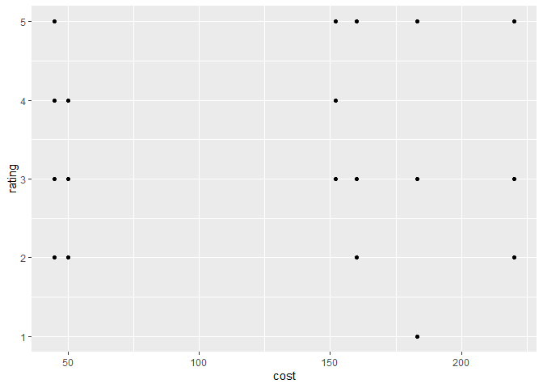

```r
ggplot(data=movie_df)+
  geom_point(mapping = aes(x=cost, y=rating))
```

There is no linear correlation between cost and rating of a movie.

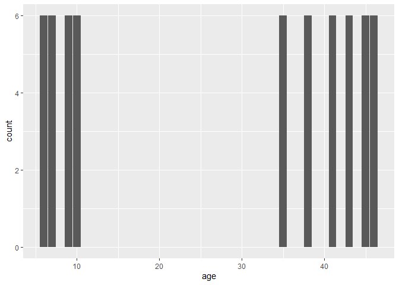

```r
ggplot(data=movie_df)+
  geom_bar(mapping = aes(x=age))
```

This shows us that , none of my family members or friends ages between 10-35 partricipated in the survey.

## Conclusion

We have collected movie survey observetaions from selected friends and family members. It is clear that the experiment requires non sample bias data(as it seems there is no response, voluntery response and convinience sample bias in the sampling) to make proper analysis and exploration.